# Assignment 4

## Exercise 2

```r
box <- df %>%
  ggplot(aes(x = manufacturer, y = hwy)) +
  geom_boxplot(outlier.colour = "red") +
  geom_jitter(alpha = 1/5) +
  scale_y_continuous(breaks = seq(min_hwy, max_hwy, 5)) +
  coord_flip() +
  xlab("Manufacturer") +
  ylab("Highway Miles per Gallon") +
  theme(axis.text = element_text(size = 10),
        axis.title = element_text(size = 12),
        panel.border = element_rect(color = "black", fill = NA, size = 1.2))
```

```r
hex <- df %>%
  ggplot(aes(x = displ, y = hwy)) +
  geom_hex(binwidth = c(0.25,1)) +
  scale_x_continuous(breaks = seq(floor(min(df$displ)), ceiling(max(df$displ)), 1)) +
  scale_y_continuous(breaks = seq(min_hwy, max_hwy, 5)) +
  scale_fill_viridis_c(option = "inferno") +
  xlab("Engine Displacement") +
  ylab("Highway Miles per Gallon") +
  theme(axis.text = element_text(size = 10),
        axis.title = element_text(size = 12),
        panel.border = element_rect(color = "black", fill = NA, size = 1.2)
        )
```

```r
viol <- df %>%
  ggplot(aes(y = hwy, x = class)) +
  geom_violin(
      scale = "area",
      fill = "darkgoldenrod1",
      color = "black",
      draw_quantiles = c(.25, .5, .75)
      ) +
  geom_jitter(alpha = 1/5) +
  scale_y_continuous(breaks = seq(min_hwy, max_hwy, 5)) +
  xlab("Vehicle Type") +
  ylab("Highway Miles per Gallon") +
  coord_flip() +
  theme(axis.text = element_text(10),
        axis.title = element_text(size = 12),
        panel.border = element_rect(color = "black", fill = NA, size = 1.2),
        )
```

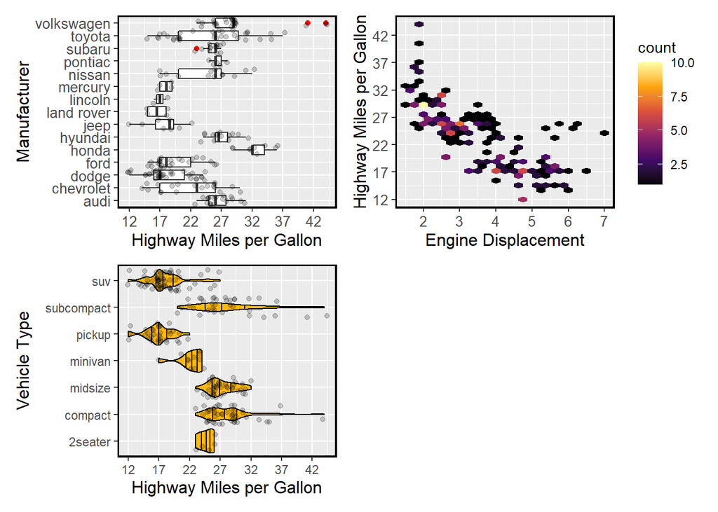

```r
box + hex + viol + plot_layout(ncol = 2)
```

```r
ggsave(
    filename = "images/04_assignment_fig3.png",
    units = "cm",
    width = 29.7,
    height = 21,
    dpi = 600
    )
```

From the above plots, it is clear that a vehicle’s highway MPG is different for different subsets of vehicles. For instance, if one were to choose a Honda, subcompact, compact or midsize vehicle, that vehicle will likely have a higher highway MPG relative to other vehicles. If one chose to drive a vehicle with low engine displacement (particularly 2 or below), that vehicle will very likely have great fuel efficiency relative to vehicles with moderate or high engine displacement.

On the other hand, pickups and SUVs tend to have much worse fuel efficiency compared to other classes, with median highway MPG much lower than in other vehicle types. Some manufacturers with lower median highway MPG include Lincoln, Mercury, Land Rover, Jeep, Ford and Dodge (with the latter 3 showing more variability). Lastly, vehicles with higher (> 4) engine displacement, tend to have lower highway MPG.